# How does character displacement affect food-web dynamics?

Matt Barbour

## Model of resource competition

We analyzed a continuous-time model of consumer-resource dynamics for two consumers ($C_1,C_2$) competing for two shared resources ($R_1,R_2$):

$$\frac{dR_1}{dt}=r_1K_1(1-\frac{R_1}{K_1})-F_{11}(R_1)C_1-F_{21}(R_1)C_2$$
$$\frac{dR_2}{dt}=r_2K_2(1-\frac{R_2}{K_2})-F_{12}(R_2)C_1-F_{22}(R_2)C_2$$
$$\frac{dC_1}{dt}=e_{11}F_{11}(R_1)C_1+e_{12}F_{12}(R_2)C_1-m_1C_1$$
$$\frac{dC_2}{dt}=e_{21}F_{21}(R_1)C_2+e_{22}F_{22}(R_2)C_2-m_2C_2$$

where $r_i$ represents intrinsic growth rates, $K_i$ represents carrying capacity, $e_{ij}$ represents the conversion efficiency of resources into new consumers, and $m_i$ represents the mortality rate of consumers. $F_{ij}(R_j)$ represents the consumer’s feeding rate (or functional response) on a specific resource (in this case, $C_i$ on $R_j$). This model is a useful characterization of a scenario where consumers compete for two distinct resources (e.g. zooplankton and benthic invertebrates) rather than if resources are better characterized by a continuous trait distribution (e.g. seed size, see Taper and Case 1985 for an example). In the scenario where consumer feeding rates increase linearly with resource density as a function of their attack rate, such that $F_{ij}(R_j)=a_{ij}R_j$, then our model becomes MacArthur’s model of resource competition (MacArthur 1972). The evolution of consumer attack rates in this model, and several extensions, have been analyzed in detail (Lawlor and Smith 1976; Abrams 1986). The general result of these analyses is that consumer divergence is an inevitable outcome of competition. In other words, the presence of a competitor causes consumers to evolve more specialized attack rates ($\frac{a_{ii}}{a_{ii}+a_{ij}}$) compared to when no competitor is present.

Here, we examine the effects of this inevitable divergence in attack rates on food-web dynamics. In particular, we examine how divergence in attack rates affects resource abundances as well as the resilience of both resources and consumers to perturbations. We do this by (i) deriving analytical expressions for the relationship between attack rates and food-web dynamics and (ii) simulate the effects of competition on the eco-evolutionary dynamics of consumers and resources. For these simulations, we used an Adaptive Dynamics approach. At each evolutionary time step, we created a mutant consumer by randomly choosing a consumer and modifying its attack rate by either subtracting or adding a small constant (0.001 in the following simulations) with equal probability. Assuming this mutant consumer was rare, we then determined whether the mutant had higher relative fitness than the resident consumer, and thus could invade and replace the resident consumer. If the mutant was able to invade, we updated the attack rate of the resident consumer to the mutant attack rate and allowed consumer and resource dynamics to reach a steady state. We then repeated the simulation 10,000 times, which was sufficient for consumers to either reach an evolutionary stable strategy (ESS, Price & Maynard Smith 1973) or an evolutionary limit (e.g. $\frac{a_{ii}}{a_{ii}+a_{ij}}$ is constrained to a maximum of 1 and minimum of 0). Our mathematical analyses show that the consequences of character displacement on food-web dynamics are not intuitive and depend critically on the foraging scenario and tradeoff in consumer attack rates.

## Effect of character displacement on resource abundances

We start by examing the effects of character displacement on the abundance of resources at equilibrium, which will also set the stage for a later analysis of food-web stability. In particular, we examine two different foraging scenarios: one where consumers forage for resource simultaneously (e.g. MacArthur 1972) and one where they cannot because resources occur in distinct habitats (e.g. Lawlor and Smith 1972; McCann 2005).

### Consumers forage for resources simultaneously

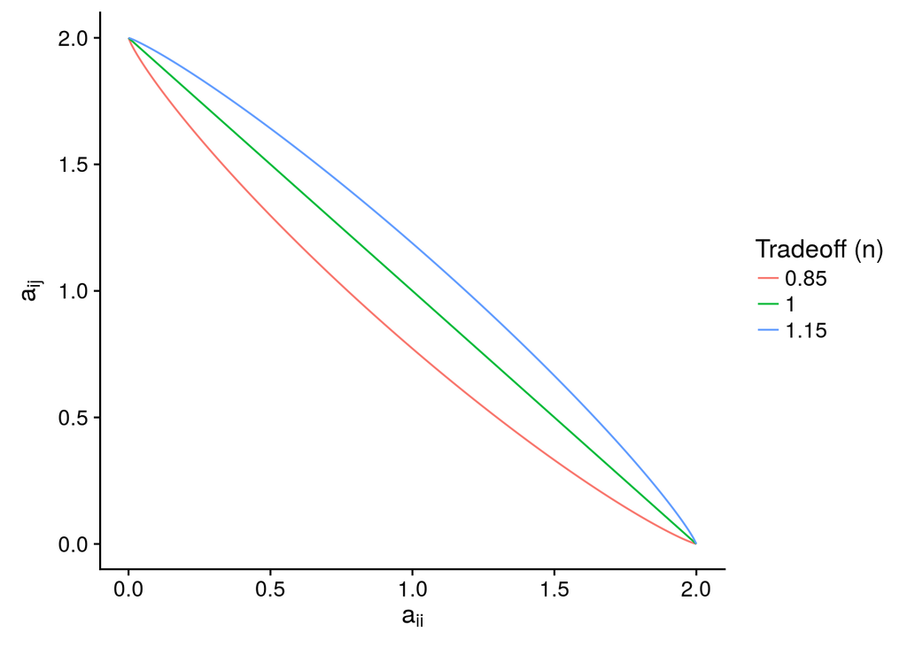

Tradeoff forms for consumer attack rates

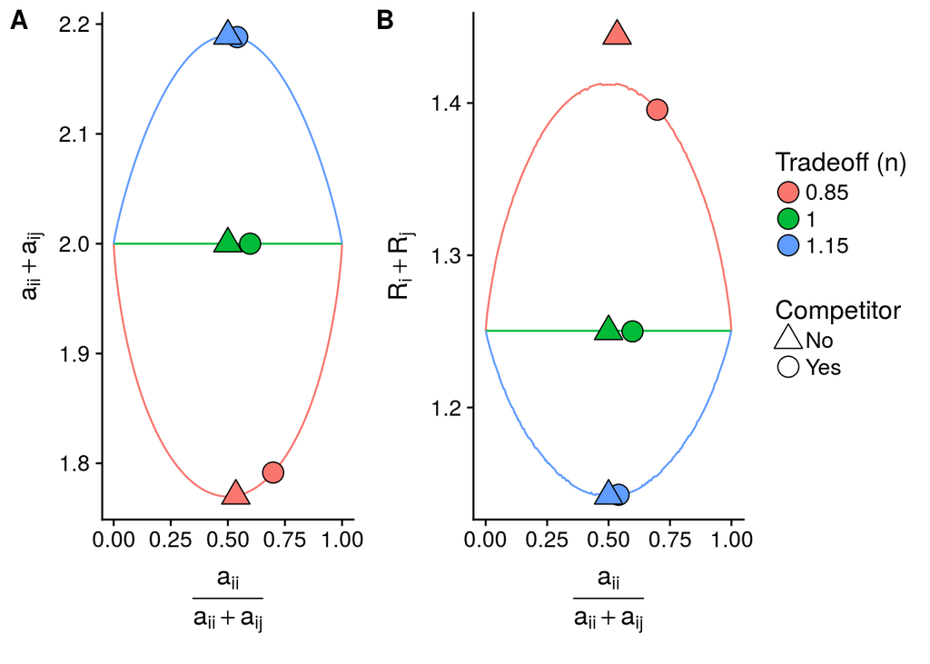

Effect of character displacement on total attack rates (A) and resource abundances (B) when both resources are found in the same habitat.

### Consumers *cannot* forage for resources simultaneously

Most models of character displacement have assumed a scenario where consumers can forage for both resources simultaneously (e.g. Taper and Case 1985; Abrams 1986). This assumption may be valid for some foraging scenarios (e.g. Darwin’s finches foraging for seeds); however, in many situations consumers forage for resources that occur in distinct habitats, and thus cannot forage for both simultaneosly. The only chracter displacement model that we are aware of that modeled resources in distinct habitats was one examined by Lawlor and Smith (1976). This model takes the same form as the previous model, except now the consumer’s functional response takes the form:

$$F_{ij}(R_j)=w_{ij}a_{ij}R_j$$

where $w_{ij}$ represents the proportion of time a consumer ($C_i$) spends foraging in a habitat where a particular resource ($R_j$) is found (i.e. habitat preference). Note that since $w_ij$ is a proportion that $w_{ii}=1-w_{ij}$. As with attack rates, we assume that consumer habitat preferences are mirror images of each other ($w=w_{11}=w_[22]$).

Lawlor and Smith (1976) found that consumers still underwent character divergence regardless of whether consumers could or could not forage for resources simultaneously. We find that the foraging scenario qualitatively affects the relationship between character divergence and resource abundances. To demonstrate this, note that now resource abundances at equilibrium (both consumers and resources present) are determined by the following equation (see derivation in Appendix):

$$\hat{R}=\frac{1}{wa_{ii}+(1-w)a_{ij}}\cdot\frac{m}{e}$$

These results do lead to an interesting prediction that could be tested either experimentally or with field data. If consumers are competing for resources that occur in distinct habitats, then greater ecological character displacement corresponds to a greater decrease in resource densities. This prediction only applies to comparisons of the effect of character displacement within species (assuming that allopatric and sympatric consumers are constrained by the same tradeoff).

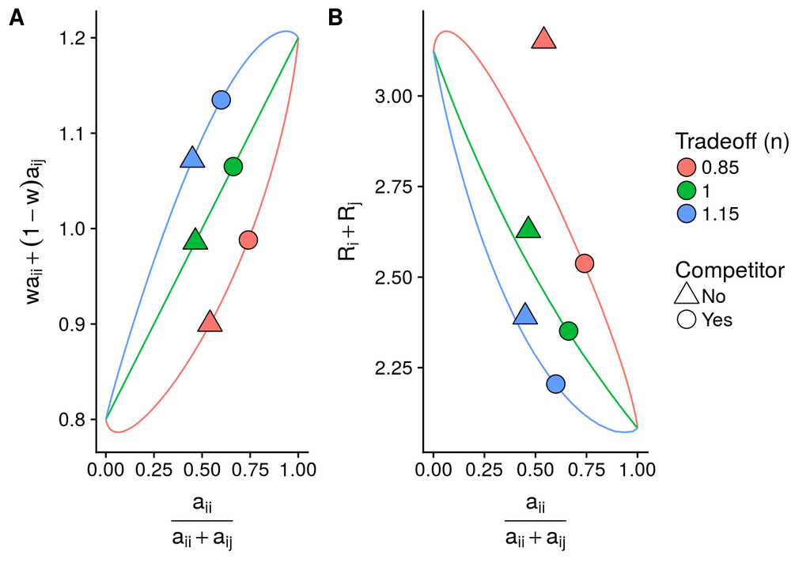

Effect of character divergence on total attack rates (A) and resource abundances (B) when each resource is found in a different habitat.

The effect of the foraging scenario on the relationship between character displacement and resource abundances appears to be quite general. For example, even if we consider a more realistic consumer functional response (derived by McCann et al. 2005):

$$F_{ii}(R_i,R_j)=\frac{a_{ii}W_{ii}R_i}{1+a_{ii}hW_{ii}R_i+a_{ij}hW_{ij}R_j}$$

where consumer feeding rates on $R_i$ are influenced by both resource densities; saturate as resource densities increase (due to handling time $h$); and consumer habitat preferences are modified by relative resource densities, such that:

$$W_{ii}=\frac{wR_i}{wR_i+(1-w)R_j}$$

we still observe the same qualitative relationship between character displacement and resource suppression (). This is because resource competition always leads to character divergence (see proof in Appendix) and equilibrium resource abundances are governed by similar dynamics:

$$\hat{R}=\frac{1}{wa_{ii}+(1-w)a_{ij}}\cdot\frac{m}{e-hm}$$

This more realistic consumer functional response does actually make an interesting evolutionary prediction that differs from the scenario where consumer feeding rate scales linearly with resource density. Specifically, a consumer’s ESS in the absence of competition will remain slightly more specialized on the resources that occur in their preferred habitats. This is in contrast to the prediction when feeding rates scale linearly with resource density, where consumers evolve to be slightly more specialized on resources occurring in their non-preferred habitats. An important caveat for these predictions is that our model does not allow habitat preferences to evolve, which would likely alter these predictions.

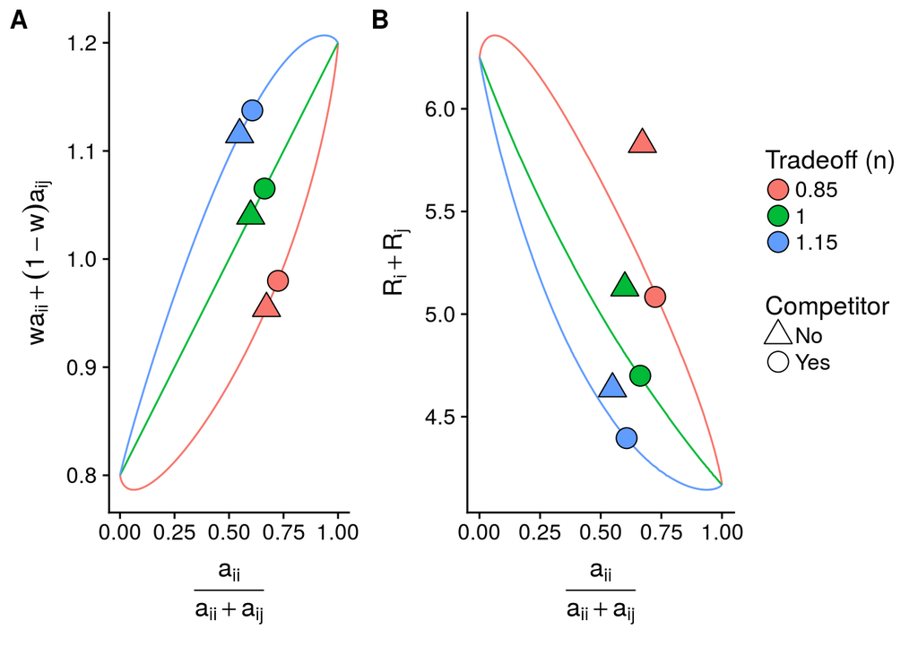

Effect of character divergence on total attack rates (A) and resource abundances (B) when consumers have a more realistic functional response. Note also that each resource is found in a different habitat.

## Effect of character displacement on food-web stability

Of the prior models of character displacement, only Lawlor and Smith (1976) examine the effect of character displacement on the ecological stability of the system. They conducted a detailed theoretical analysis of three different metrics of stability: (i) stable coexistence of consumers, defined as the mutual invasibility of each consumer; (ii) global stability of consumers, defined as the continued coexistence of both consumers when resources dynamics are perturbed; and (iii) local stability, defined as the rate at which the four-species community returns to equilibrium after a small perturbation to species abundances. Note that the first two metrics correspond to the stable coexistence of consumers, while the third metric measures the stability of the entire system. Lawlor and Smith found that character displacement enhanced the stable coexistence of consumers, yet had a small negative effect on the resilience of the system.

Lawlor and Smith’s work gave fundamental insight to the effect of character divergence on ecological stability; however, none of their stability analyses compared food webs with and without a competing consumer. Such comparisons are necessary for inferring the effects of ecological character displacement, a point that has been made clear in the criteria to demonstrate character displacement (Schluter and McPhail 1992; Schluter 2000). In fact, the first two metrics of stability can only be assessed when both consumers are present because it interprets the effect of divergence in the presence of a competitor —not in its absence. In contrast, local stability can be compared in food webs with and without a competing consumer, and thus provides a useful benchmark for exploring the effects of character displacement on food-web stability.

Below, we plot the results from the same simulations we did previously except now local stability ($-1\times\operatorname{Re}(\lambda_{max})$) is on the y-axis (). In general, we find that resource surpression goes hand-in-hand with local stability, a tendency that has been noted by others (Murdoch et al. 2003; McCann 2012). Whenever ecological character displacement results in resource suppression, we observe a decrease in local stability (). This is not simply a consequence of having an additional consumer in the system, but emerges from the eco-evolutionary feedback between character displacement and resource suppression (compare initial points (small points) with evolved strategies (large points), ).

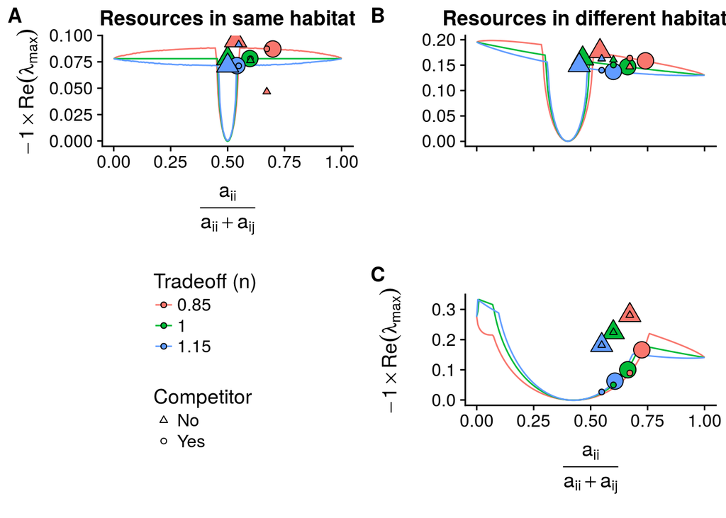

Effect of character displacement on local stability across different foraging scenarios and tradeoffs in attack rates. Small and large points correspond to the beginning and of the simulation, respectively.

$$wa_{ii}+(1-w)a_{ij} > \frac{e+hm}{hK(e-hm)}$$

Previously, we showed that character displacement always increases the effective attack rate of consumers ($wa_{ii}+(1-w)a_{ij}$), regardless of the the shape of the tradeoff. Thus, ecological character displacement can push food webs toward the boundary of local stability (i.e. where the system transitions from having a stable equilibrium point to a limit cycle).

### Predictions for threespine stickleback

While measuring resource densities is relatively straightforward, measuring stability is notoriously difficult. One of the more easy to acquire empirical metrics of stability is the coefficient of variation ($CV=\frac{\sigma}{\mu}$) as this only requires measurements of resource (or consumer) densities over time. Interestingly, there is a close correspondence between the coefficient of variation and the local stability of a food web (Gellner et al. 2016). This close correspondence emerges from the fact that stochastic perturbations in resource (or consumer) abundances will determine the variability in abundances. And since food webs are constantly buffeted by stochastic processes in the real world, we expect that our predictions using local stability would correspond to the $CV$ of resources (or consumers). Thus, we predict that character displacement in threespine stickleback will increase the $CV$ of resource (or consumer) densities.

Consumer and resource densities in our model can be interpreted from either a population or biomass perspective (Yodzis and Innes 1992; Murdoch et al. 2003; McCann 2012). For the stickleback system, we had data on seasonal dynamics of resources in terms of both abundances and biomass. Within a season, we do not expect stickleback abundances to be coupled to the abundances of zooplankton and benthic invertebrates, given that sticklebacks reproduce annually whereas zooplankton and benthic invertebrates can reproduces many times within a season. Instead, we expect that stickleback biomass will be coupled to the biomass of zooplankton and benthic invertebrates within a season. This is because there will be lots of young stickleback at the beginning of the season, and they will eat a lot of resources and grow in size as the season progresses. If this is true, we also expect to see the largest negative effect of stickleback on resource densities late in the season.

### Other relevant points

Although we used an Adaptive Dynamics approach here, we expect that our results would apply to models that assumed a different genetic architecture of attack rates (e.g. quantitative genetics, Taper & Case 1985). We expect this because, time and time again, models that explicitly include resource dynamics inevitably show that resource competition results in divergent charactere displacement, regardless of the genetic architecture of traits (see synthesis by Taper & Case 1985). Finally, our conclusions only apply to biological resources that are nutritionally substitutable. It would be interesting to extend our current analyses to those situations.